# Bent Spring 2001

R. G. Cronce

12/19/2019

# Bent Brain Ticklers, Spring 2001

## Problem 1

```
A local eatery has an electronic
"slot machine" that offers various
games. In one of them, called
PrimeTime, after a coin is inserted,
the digits 1 through 9 appear in
random order around a circle. Then,
an arrow, like the minute hand on a
clock, spins and stops, pointing to the
space between two of the digits. If
the two-digit number formed in a
clockwise direction by the two digits
on either side of the space the arrow
points to has a two-digit prime
factor, you win the jackpot. For
example, if the arrow stopped
between 9 and 2, you would win
because 92 has the prime factor 23.
On the other hand, if your number
were 81, you would lose. I recently
played the game; and, as the arrow
was spinning, I realized to my
dismay that no matter where the
arrow stopped, I would lose. Starting
with 1, what was the clockwise order
of the digits?

-- Susan Denham in New Scientist
```

Solution:

Could generate all the permutations and then check them. Seems excessive.

Could enumerate all the two digit primes and their multiples to look for patterns. For example, I might find that a 9 can never be preceded by the number 8 (since 89 is prime). If I can find any digits that only permit a single successor/predecessor then I will have part of the sequence. The sequence we are looking for should be revealed from this pattern analysis:

```r
is_prime = function(n) {
  if (n<4) {
    if (n==2 | n==3) { return(TRUE) }
    return(FALSE)
  }
  if (n%%2 == 0) { return(FALSE) }
  for (i in 3:sqrt(n)) {
    if (n%%i == 0) { return(FALSE) }
  }
  return(TRUE)
}

p=(1:100)[sapply(1:100,is_prime)]
p=p[p>9]

print("Two digit primes:")
```

```
## [1] "Two digit primes:"
```

```r
print(p)
```

```
##  [1] 11 13 17 19 23 29 31 37 41 43 47 53 59 61 67 71 73 79 83 89 97
```

```r
# Generate all the integer multiples of these primes up to 9*11=99
# Remove all the results above two digits
#
# These results are Poison (we want to avoid them)
p=as.vector(outer(1:9,p,'*'))
p=p[p<100]

print("Two digit primes and multiples:")
```

```
## [1] "Two digit primes and multiples:"
```

```r
p
```

```
##  [1] 11 22 33 44 55 66 77 88 99 13 26 39 52 65 78 91 17 34 51 68 85 19 38
## [24] 57 76 95 23 46 69 92 29 58 87 31 62 93 37 74 41 82 43 86 47 94 53 59
## [47] 61 67 71 73 79 83 89 97
```

```r
print("Patterns based on final digit:")
```

```
## [1] "Patterns based on final digit:"
```

```r
for (i in 1:9) {
  print(c(i,sort(p[p%%10 == i])))
}
```

```
## [1]  1 11 31 41 51 61 71 91
## [1]  2 22 52 62 82 92
## [1]  3 13 23 33 43 53 73 83 93
## [1]  4 34 44 74 94
## [1]  5 55 65 85 95
## [1]  6 26 46 66 76 86
## [1]  7 17 37 47 57 67 77 87 97
## [1]  8 38 58 68 78 88
## [1]  9 19 29 39 59 69 79 89 99
```

```r
print("Patterns based on initial digit:")
```

```
## [1] "Patterns based on initial digit:"
```

```r
for (i in 1:9) {
  print(c(i,sort(p[trunc(p/10) == i])))
}
```

```
## [1]  1 11 13 17 19
## [1]  2 22 23 26 29
## [1]  3 31 33 34 37 38 39
## [1]  4 41 43 44 46 47
## [1]  5 51 52 53 55 57 58 59
## [1]  6 61 62 65 66 67 68 69
## [1]  7 71 73 74 76 77 78 79
## [1]  8 82 83 85 86 87 88 89
## [1]  9 91 92 93 94 95 97 99
```

From the results above we conclude:

```
--> indicates a conclusion based strictly on the patterns above.
Other comments and eliminated digits occur based on these primal
patterns and the observation that a digit can only occur before or
after another digit (not in both places - e.g. 2 relative to 7):

1 must be preceded by 8                 must be -8-1-
2 must be preceded by 1, 3, 7
3 must be preceded by 6  -->            must be -6-3-
4 must be preceded by 1, 5
5 must be preceded by 1, 3, 7
6 must be preceded by 1, 3, 5, 9
7 must be preceded by 2  -->            must be -2-7-
8 must be preceded by 1, 9
9 must be preceded by 4  -->            must be -4-9-

1 must be followed by 2, 4, 5, 6, 8
2 must be followed by 7
3 must be followed by 2, 5, 6
4 must be followed by 9
5 must be followed by 4, 6
6 must be followed by 3
7 must be followed by 2, 5 -->          must be -2-7-5-
8 must be followed by 1
9 must be followed by 8                 must be -9-8-
```

Merging some of the partial patterns:

```
-4-9-8-1-  as a result of -4-9- and -9-8- and -8-1-
-2-7-5-    as a result of 2 must precede 7 so it can't also follow
-6-3-      primal pattern
```

But 4 must be preceded by 1, 5 so:

```
-2-7-5-4-9-8-1-  as a result of -2-7-5- and -4-9-8-1-
-6-3-
```

And, 6 must be preceded by 1,3,5,9:

```
-2-7-5-4-9-8-1-6-3- ...
```

If we circularly shift to start with 1:

```
... -1-6-3-2-7-5-4-9-8- ...
```

Then the game can only generate numbers with single digit prime factors:

[output not shown]

Just for grins, let’s try the permutation method:

```r
library(gtools)

t1=Sys.time()
# a is the permutation matrix with 1 in the left-most column
# The remaining columns are all permutations of the digits 2-9
a=cbind(1,gtools::permutations(8,8,2:9))
# b is the two digit number made with digits from adjacent columns of a.
# This also wraps around from the end of the a matrix back to column 1.
b=10*a+cbind(a[,2:9],a[,1])

# Check each of the permutations to see if they contain any of the
# target values (in p).  If so - then that is not what we want.
k=apply(b,1,function(x) {any(x %in% p)})
t2=Sys.time()

print(t2-t1)
```

```
## Time difference of 0.5478468 secs
```

```r
# Find all the rows that are "losers" -- e.g. have no two digit prime factors
a[which(k==FALSE),]
```

```
## [1] 1 6 3 2 7 5 4 9 8
```

Which yields the same answer and runs very quickly. It is actually amazing that there is only one combination that yields this result.

As a corollary: what is the expected payout from this game? What percent of the time can you actually get a two digit prime factor?

We can use the results from above to calculate this:

```r
m=apply(b,1,function(x) {sum(x %in% p)})
sum(m)/length(b)
```

```
## [1] 0.625
```

Amazingly, 5/8 of the time you will actually have a two digit prime factor!

This also means that 3/8 of the time you will not have a two digit prime factor. If we assumed the 9 spaces on the wheel were statistically independent (not a good assumption), then we could estimate the likelihood of an entire wheel that has no two digit prime factor as:

```r
(3/8)^9*nrow(a)
```

```
## [1] 5.912919
```

So we expect that about 6 rows of the permutation matrix has no two digit prime factor. Actually the result is 1 which is remarkably close to the random assumption calculation – at least it is within an order of magnitude.

## Problem 2

```
Don't let the wording of this
cryptic fool you into thinking it is
solvable in base 10. It isn't.

TEN x TEN - TEN = NINETY

Your job is to solve it in the
smallest base for which a solution
exists.

-- Journal of Recreational Mathematics
```

Solution:

There are only 5 symbols used in the equation above. This means that the base must be at least base 5. We could exhaustively search for solutions to the cryptic problem but the number of permutations increases rapidly with the base number but it should be feasible up to base 20 or so:

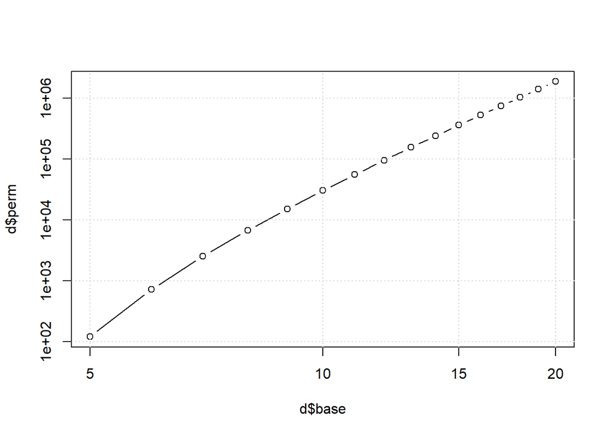

```r
d=data.frame(base=5:20)
d$perm=choose(d$base,5)*factorial(5)
plot(d$base,d$perm,type='b',log="xy")
grid()
```

Let’s try this:

```r
# Get the code to play with cryptic arithmetic problems
source('rgc_lib.R')
```

We will verify this doesn’t work in base-10:

```r
a=make_crypt_df('tenninety',10)
x10=make_num(a,'ten',10)
x90=make_num(a,'ninety',10)
k=(x10*x10-x10 == x90) & (a$t != 0)
sum(k)
```

```
## [1] 0
```

I tried several base values up through 32 without any solutions. Need to think this through - let’s try symbolically:

```
TEN*TEN-TEN = TEN*(TEN-1) = NINETY

TEN ~ sqrt(NINETY)  --> TEN is just slightly more than sqrt(NINETY)

number of digit in NINETY = 6, TEN = 3.  TEN must exceed sqrt(base) to add digit.

TEN = T*b^2 + E*b + N
NINETY = N*b^5 + I*b^4 + N*b^3 + E*b^2 + T*b + Y
```

So:

```
TEN*TEN-TEN = (T*b^2 + E*b + N)*(T*b^2 + E*b + N) - (T*b^2 + E*b + N)

    T^2       b^4
    2*E*T     b^3
    2*N*T+E^2 b^2
    2*N*E     b
    N^2

NINETY = N*b^5 + I*b^4 + N*b^3 + E*b^2 + T*b + Y
```

TODO – need to work on this some more

## Problem 3

```
I recently visited a small aviary
and asked the keeper how many
birds he had. He replied, "I have a
total of 401 birds of five different
species. The number of auks is a
fourth power, although they will be
breeding soon. I have more than ten
boobies, and their number is both a
palindrome and triangular. The
number of cuckoos is divisible by 13.
The number of doves, which is more
than the number of auks, is prime
and a Fibonacci number. More than
five-eighths of the four species I
have mentioned so far are auks and
cuckoos. How many eagles do I
have?" (A triangular number has the
form n(n + 1)/2, where n is a positive
integer. Such numbers can be
arranged in triangles, like bowling
pins.)

-- The Platinic Corner
```

Solution:

```
Total number of birds = 401
Five species, each has count less than 401

auks = fourth power > 1 (if breeding) --> [16, 81, 256]
boobies = triangular, palindrome > 10 --> [55, 66, 171]
cuckoos = divisible by 13
doves   = prime, Fibonacci > auks
  prime, Fibonacci = [89, 233] --> auks can not be 256.
auks+cuckoos > 5/8*(auks+cuckoos+doves+boobies)

    boobies >= 55
    doves   >= 89

    auks+cuckoos > 5/8*(auks+cuckoos+doves+boobies)
    3*(auks+cuckoos) > 5*(doves+boobies) >= 5*(55+89)
    auks+cuckoos >= 240

This is starting to get confusing -- let the computer do the search.

eagles  = unknown = 401-(auks+boobies+cuckoos+doves)
```

```r
a=data.frame(auks=NA,boobies=NA,cuckoos=NA,doves=NA,eagles=NA)
for (auks in c(16,81)) {
  for (boobies in c(55,66,171)) {
    for (cuckoos in (1:30)*13) {
      for (doves in c(89,233)) {
        if ((auks+cuckoos) > 5/8*(auks+cuckoos+doves+boobies)) {
          if ((auks+cuckoos+doves+boobies)<401) {
            a=rbind(a,c(auks,boobies,cuckoos,doves,401-(auks+boobies+cuckoos+doves)))
          }
        }
      }
    }
  }
}
a=a[!is.na(a$auks),]
row.names(a)=1:nrow(a)
a
```

```
##   auks boobies cuckoos doves eagles
## 1   16      55     234    89      7
## 2   81      55     169    89      7
```

The number of eagles must be 7.

The number of boobies must be 55, number of doves must be 89. The number of auks and cuckoos can vary as noted in the solution.

## Problem 4

```
An urn contains nine balls labeled 1
through 9. Draw out the balls one at
a time and line them in the order
drawn to form a nine-digit number.
What is the probability that the
number so formed is divisible by 11?

-- Technology Review
```

Solution: try Monte-Carlo

```r
n_trials=1000000
n=0
for (i in 1:n_trials) {
  s=0
  for (j in sample(1:9,9)) {s=10*s+j}
  if (s%%11 == 0) { n=n+1 }
}
n/n_trials
```

```
## [1] 0.087629
```

I could also look at the divisibility rules on Wikipedia and see if there is a tricky way to find divisibility by 11.

I could also check out all the 9 digit permutations. This should be feasible since there are only 9! permutations to consider:

```r
library(e1071)
a=permutations(9)

s=rep(0,nrow(a))
for (i in 1:ncol(a)) { s=10*s+a[,i] }

n=sum(s%%11 == 0)

n/nrow(a)
```

```
## [1] 0.08730159
```

This is the result of exhaustive search. It compares well with the result from Monte-Carlo:

[output not shown]

## Problem 5

```
A pentomino is a plane figure
constructed from five unit squares
joined along their edges. A complete
set of pentominoes consists of one of
each of the 12 different such figures.
Rotations and reflections are allowed
but do not count as different figures.
Starting with a complete set whose
squares are the size of chessboard
squares, what is the smallest number
of pentominoes that can be placed on
a chessboard so that none of the
remaining pentominoes can be placed
on the board? Pentominoes must be
placed so that they are congruent
with the squares of the chessboard,
and they cannot overlap. To see what
a complete set of pentominoes looks
like, see the Brain Ticklers column in
the Fall 1999 issue of THE BENT. We
like to assign the letter names F, I,
L, N, P, T, U, V, W, X, Y, and Z,
which the pentominoes at least
somewhat resemble.

-- Mathematics Teacher
```

TODO

## Bonus

```
An anti-aircraft gun with
muzzle velocity v can be fired at any
azimuth or elevation by vertical and
horizontal rotation about its fixed
location. What is the total volume of
sky that can be reached by a shell
from the gun, i.e., what is the
envelope of coverage? Assume the
land in the vicinity of the gun is level,
and ignore wind and air resistance.
Express your answer as a function of
v and the gravitational constant g.

-- Richard W. de Nobel, OH Alpha'52
```

Solution:

```
We should be able to calculate the volume using
slices in the horizontal direction and then calculating
the distance (radius) achievable at the optimal
firing angle.  These will be differential discs
that can be summed from 0 to ymax to yield the
total volume.

Assume the target height is y0.  We need to find
the largest x that can be achieved at this height.

Under uniform acceleration:

    v = a*t
    x = 1/2*a*t^2

Assume firing angle is theta, then:

vx0=v*cos(theta)
vy0=v*sin(theta)

Time to reach max altitude: t1=vy0/g
Max altitude: ymax=1/2*g*(vy0/g)^2 = vy0^2/(2*g)
Time to fall: t2=sqrt(2*(ymax-y0)/g)
Total flight time = t1+t2
Distance (x-axis) = vx0*(t1+t2)

Substituting:

  xmax = v*cos(theta)*(v*sin(theta)+sqrt(2*(v^2*sin(theta)^2/(2*g)-y0)/2))

Want to maximize wrt theta (need sympy -- this is ugly):

Unfortunately, this gets ugly and stays ugly!

Sympy ran for several minutes trying to integrate this so I killed it.

The sympy expressions seemed correct for y0=0 using some numerical
values for v, g.

Conceptually this works -- but maybe need a different way to find
the volume.

For a given x (radius) there should be a maximum altitude.  Is it possible
to find this and then sum up differential cylinders?

I gave up -- but this would have been the way to go.

This is the approach taken in the Bent and they
express y=f(x,theta) and then maximize y wrt theta with dy/dtheta=0.
Solving this gives the relationship between x and theta which can be
used to eliminate theta and get an equation for x and ye (envelope).

Once this relationship is known we can just integrate the cylinders from 0
to the maximum possible firing distance.

From the Bent:

x = v*t*cos(theta)
y = v*t*sin(theta) - 1/2*g*t^2

elimination of t leads to:

t=x/(v*cos(theta))
y=v*x/(v*cos(theta))*sin(theta) - 1/2*g*x^2/(v*cos(theta))^2
 = x*tan(theta) - x^2*g/(2*v^2*cos(theta)^2)

Let: h = v^2/(2*g) = maximum height when firing straight up

y = x*tan(theta) - x^2 * 1/(4*h*cos(theta)^2)

The maximal y for a given x defines a point on the envelope.
To find the maximal y we need dy/dtheta = 0

this is maximized when x=2*h/tan(theta) or

theta = atan(2*h/x)

so:

ye = h-x^2/(4*h)  (yes - I used sympy to simplify this)

so, now:

we can constuct differential cylinders (as I suspected above) and
calculate the volume:

integrate(2*pi*x*ye,(x,0,xmax))

where xmax = maximum possible x value which occurs for theta=45 degrees.

xmax:  vy0=v*sin(45*pi/180)=v/sqrt(2)
       vx0=v*cos(45*pi/180)=v/sqrt(2)
       t = 2*vy0/g
       xmax = 2*v/sqrt(2)*v/sqrt(2)/g
            = v^2/g
            = 2*h (from above)

so: V = integrate(2*pi*x*(h-x^2/(4*h)),(x,0,2*h))
      = 2*pi*h**3

or:

    v = 2*pi*((v^2)/(2*g))^3
      = 2*pi*v^6/(8*g^3)
      = pi*v^6/(4*g^3)
```

We should be able to do this with reticulate and sympy:

```r
library(reticulate)
```

```python
import sympy
from sympy import *

x,y,theta,t,g,v = symbols('x y theta t g v',positive=True)

xpos=v*t*cos(theta)
ypos=v*t*sin(theta)-g*t**2/2

# Solving the first equation for t:
tval=solve(xpos-x,t)[0]

# and substituting into the second eliminates t.
# Need to find the value of theta that maximizes this height for a given x
thetaval=solve(diff(ypos.subs(t,tval),theta),theta)[0]
pprint(Eq(S('theta_for_ye'),thetaval))

# If we substitute back into equation for y then we have the desired function
# This is the height of the envelope (aka differential cylinder of radius x)
```

```
##                       /         ____________\
##                       |        /  2  2    4 |
##                       |g*x - \/  g *x  + v  |
## theta_for_ye = -2*atan|---------------------|
##                       |           2         |
##                       \          v          /
```

```python
ye=simplify(ypos.subs(t,tval).subs(theta,thetaval))
pprint(Eq(S('ye'),ye))

# Now we need to integrate differential cylinders over x from 0 to xmax.
# xmax occurs when the firing angle is 45 degrees
# The time the projectile is in the air is 2*time for projectile to reach peak.
# The speed in the x direction is constant
```

```
##           2     2
##        g*x     v
## ye = - ---- + ---
##           2   2*g
##        2*v
```

```python
tmax=2*(v*sin(pi/4)/g)
xmax=v*cos(pi/4)*tmax
pprint(Eq(S('xmax'),xmax))

# Now we can integrate
```

```
##         2
##        v
## xmax = --
##        g
```

```python
pprint(Eq(S('Volume'),integrate(2*pi*x*ye,(x,0,xmax))))
```

```
##              6
##          pi*v
## Volume = -----
##              3
##           4*g
```

```python
print()
```

```python
print("Alternate expression:")
```

```
## Alternate expression:
```

```python
print()

# Alternately
```

```python
pprint(Eq(S('Volume'),pi/4*S('xmax')**3))
```

```
##                 3
##          pi*xmax
## Volume = --------
##             4
```

I am actually starting to wonder what this envelope looks like. Using the results from above we should be able to just plot it:

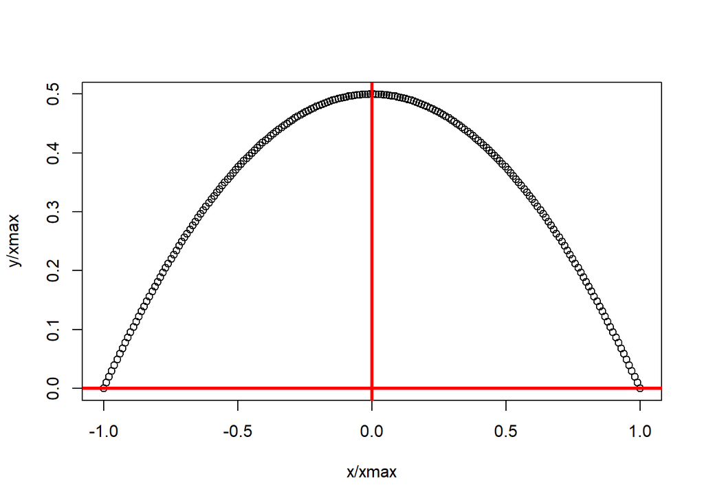

```r
v=100
g=32.2
xmax=v^2/g

x=seq(-xmax,xmax,length=200)
y=-g*x^2/(2*v^2)+v^2/(2*g)

plot(x/xmax,y/xmax,type='b')
abline(h=0,col='red',lwd=3)
abline(v=0,col='red',lwd=3)
```

Looking again at the equations shows the envelope is quadratically related to the maximum firing range:

[output not shown]

We could probably use this calculate the volume as well – but we will leave that for another day.

## Double Bonus

```
A 9-ft. by 12-ft. rug
has a centered 1-ft. by 8-ft. hole, with
the 8-ft. dimension parallel to the 12-ft.
side. Show how to cut the rug into
two pieces that can be fit together to
form a 10-ft. by 10-ft. rug with no
hole.

-- Author not specified
```

TODO

```
I have seen this problem before.  Make a staircase
and shift it one step.
```